# Cumulative Sum

Jyotishka Datta

October 12, 2017

## Cumulative Sum

We generate $n = 1000$ random numbers $X_1, \ldots, X_n \sim N(\mu, \sigma)$ from a Normal distribution with mean $\mu = 0.033$ and standard deviation $\sigma = 5.19$ (These are values from some simulation experiments done before).

The outputs are below. As expected, the normalization makes the series staionary but reduces the variance almost to zero as $k$ grows big.

[figure not shown]

```r
set.seed(222)
mu = 0.033
sigma = 5.19
x = rnorm(1000, mu, sigma)
par(mfrow=c(1,1))
plot(cumsum(x),type="l",col="red")
lines(x,col="blue")
z = cumsum(x)
z_std = (cumsum(x)-mu*seq(1,length(x)))/(sqrt(seq(1,length(x)))*sigma)
lines(z_std, lwd= 2, col="magenta")
legend("topleft",c("N(mu,sigma)", "Cum-sum", "Normalized Cum-sum"), col=c("red","blue","magenta"),lty = c(1,1,1))
```

If we have two sensors and measure the angle between them as
$$\theta_i = (x_{1i}-x_{2i})/d$$
where $d$ is the distance between the two sensors and $x_{1i}$ and $x_{2i}$ are the measurements between times $t(i)$ and $t(i+1)$. How would the cumulative sum of the angles behave? The variance would ideally depend on the distance $d$, but the general nature should be same as that of the cumulative sum of the Normal variates.

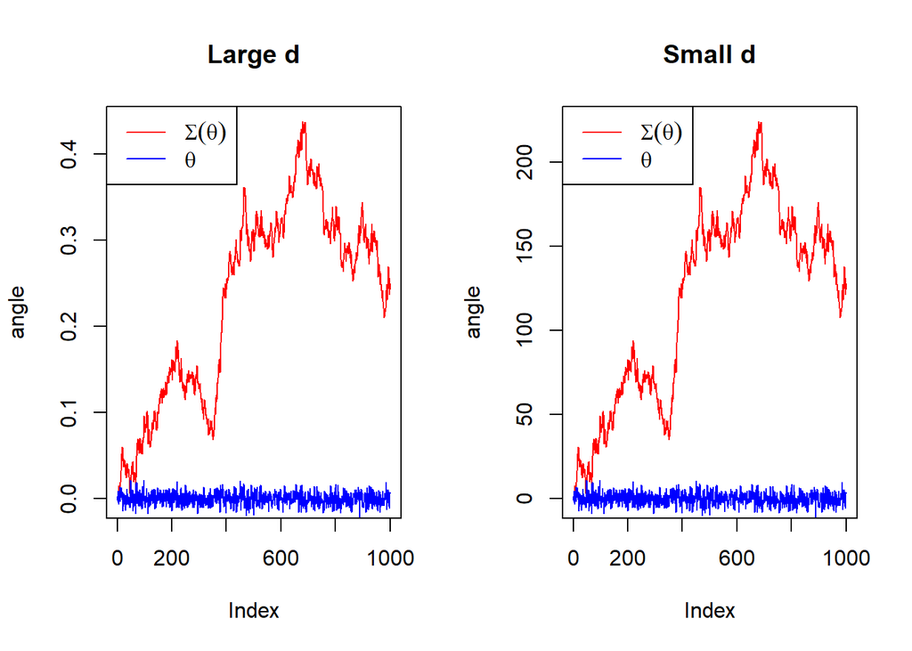

```r
x1 = rnorm(1000, mu, sigma)
x2 = rnorm(1000, mu, sigma)
d = 2
theta_large  = (x1-x2)/d
theta_small = (x1-x2)/(d^10)

par(mfrow=c(1,2))
plot(cumsum(theta_small),type="l",col="red", ylab = "angle", main = "Large d")
lines(theta_small,col="blue")
legend("topleft",c(expression(Sigma(theta)),expression(theta)), col=c("red","blue"),lty = c(1,1))
plot(cumsum(theta_large),type="l",col="red",ylab = "angle", main = "Small d")
lines(theta_large,type="l",col="blue")
legend("topleft",c(expression(Sigma(theta)),expression(theta)), col=c("red","blue"),lty = c(1,1))
```